# Discriminante Lineal

30 de octubre de 2015

## Data Set

## Pima Indians Diabetes

- El conjunto de datos cuenta con 768 observaciones de detalles clínicos de pacientes provenientes de la comunidad Pima.
- Cada observación nos dice la edad, número de embarazos e información del análisis de sangre.
- Mujeres que tienen por lo menos 21 años de edad.
- Los atributos son numéricos.
- Una variable de clase que indica si la paciente sufrió aparición de diabetes dentro de los 5 primeros años.
- 500 Observaciones tiene la clase 0 y 268 la clase 1.

Los datos fueron obtenidos de:

https://archive.ics.uci.edu/ml/datasets/Pima+Indians+Diabetes

**Propietarios originales** : Instituto Nacional de Diabetes y Enfermedades Digestivas y del Riñón

**Donador de la base de datos** : Universidad Johns Hopkins

## Variables

1. Número de embarazos
2. Concentrado de plasma de glucosa por 2 horas en una prueba de tolerancia oral
3. Presión arterial (mm Hg)
4. Medida de tríceps (mm)
5. 2-Horas de insulina en suero (mu U/ml)
6. Índice de masa corporal
7. Función Diabetes pedigree
8. Edad
9. Variable clase (0 ó 1)

## Implementación

## Procesamiento de datos

Leemos los datos y revisamos su estructura

```r
datos <- read.csv(file = "pima-indians-diabetes.csv")
str(datos)
```

```
## 'data.frame':    768 obs. of  9 variables:
##  $ Numero_de_Embarazos : int  6 1 8 1 0 5 3 10 2 8 ...
##  $ Concentracion_Plasma: int  148 85 183 89 137 116 78 115 197 125 ...
##  $ Presion             : int  72 66 64 66 40 74 50 0 70 96 ...
##  $ Tricep              : int  35 29 0 23 35 0 32 0 45 0 ...
##  $ Insulina            : int  0 0 0 94 168 0 88 0 543 0 ...
##  $ IMC                 : num  33.6 26.6 23.3 28.1 43.1 25.6 31 35.3 30.5 0 ...
##  $ Diabetes_Fun        : num  0.627 0.351 0.672 0.167 2.288 ...
##  $ Edad                : int  50 31 32 21 33 30 26 29 53 54 ...
##  $ Clase               : int  1 0 1 0 1 0 1 0 1 1 ...
```

## Visualización de las clases

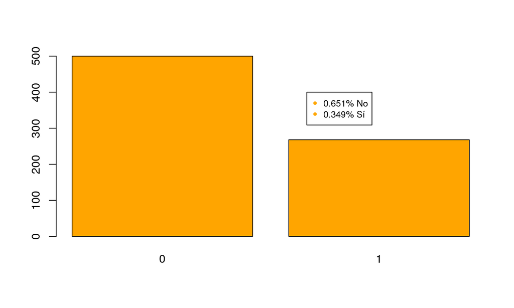

## Análisis de Componentes Principales

```
## Importance of components:
##                             Comp.1      Comp.2      Comp.3      Comp.4
## Standard deviation     115.9269227 30.52123197 19.75017130 14.06856925
## Proportion of Variance   0.8885466  0.06159078  0.02579012  0.01308614
## Cumulative Proportion    0.8885466  0.95013742  0.97592754  0.98901367
##                              Comp.5      Comp.6       Comp.7       Comp.8
## Standard deviation     10.608599547 6.765335861 2.7839906427 3.205262e-01
## Proportion of Variance  0.007440939 0.003026149 0.0005124449 6.792643e-06
## Cumulative Proportion   0.996454613 0.999480762 0.9999932074 1.000000e+00
```

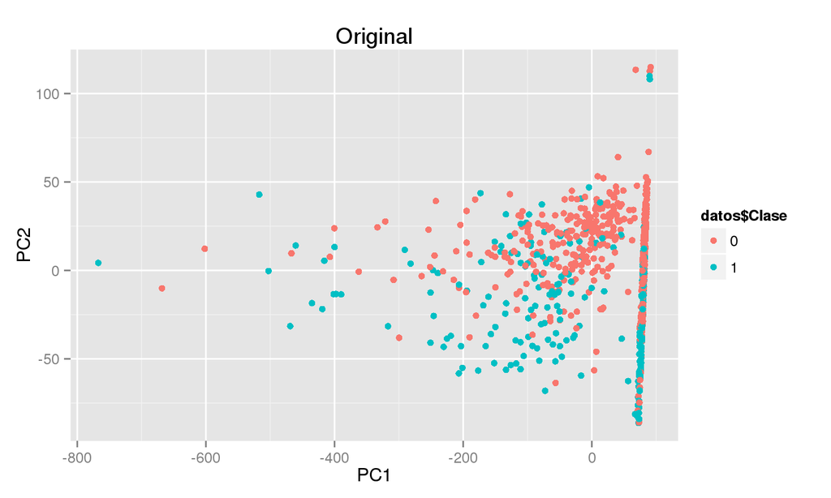

## Discriminante Lineal

```r
library(MASS)
attach(sub.datos)

lda.mod <- lda(Clase ~ .,datos)
lda.mod.p <- predict(lda.mod, newdata = sub.datos)$class
lda.mod$scaling  # Coeficientes de los hiperplanos
```

```
##                                LD1
## Numero_de_Embarazos   0.0938638298
## Concentracion_Plasma  0.0269863520
## Presion              -0.0106293929
## Tricep                0.0007043468
## Insulina             -0.0008229296
## IMC                   0.0603702056
## Diabetes_Fun          0.6711517147
## Edad                  0.0119490869
```

## Resultados

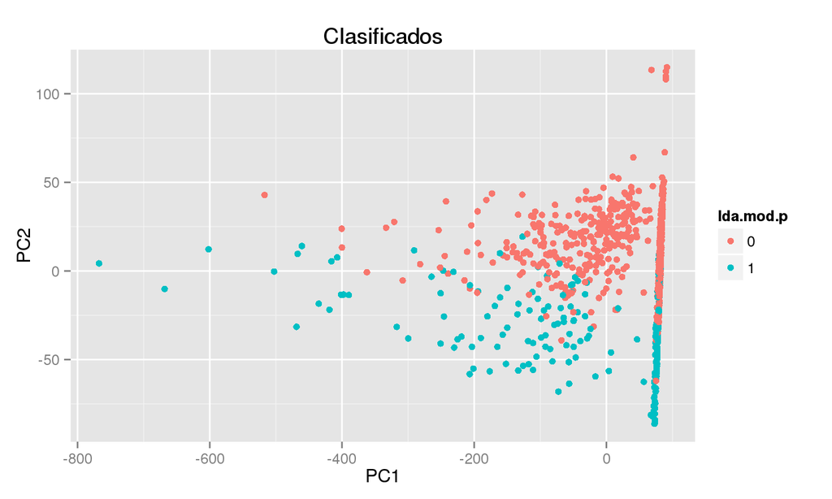

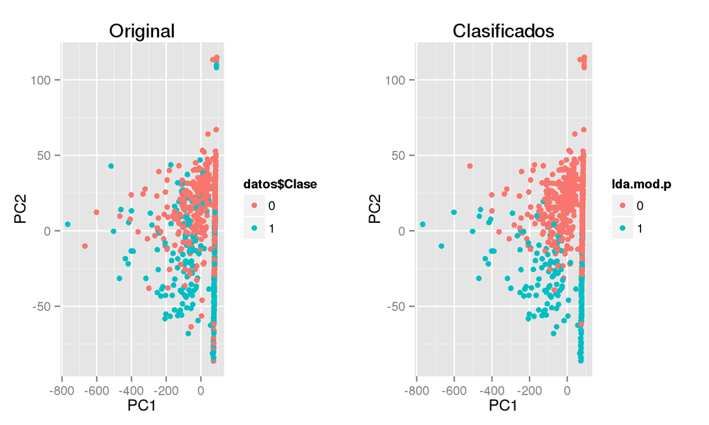

## Cross Validation

```r
ajuste <- function(arr, n){
  sum <- 0

  for(i in 1:nrow(arr))
  {
    sum <- sum + arr[i,i]
  }
  sum / n

}

cross_val <- lda(Clase ~ ., data = datos, CV = T)$class
cuentas_clase <- table(datos$Clase,cross_val )
fit <- ajuste(cuentas_clase, nrow(datos))
```

**Ajuste del modelo** : **77.4739583%**

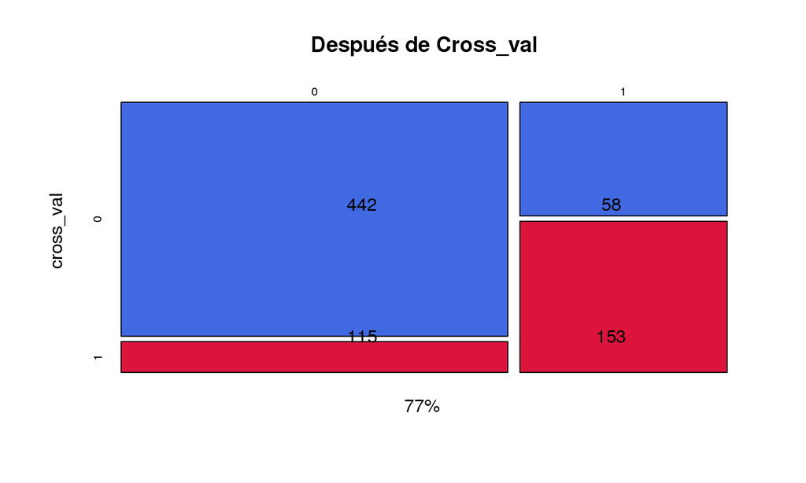